# Danish kings duration of reign through time

Nanna Elkjær-Larsen

2022-11-29

Dataframe on danish kings duration of reign through time

## Load dataframe

I firstly need to load the dataframe and define it as an object

```r
read_csv2("data/kings_3-kopi.csv")
```

```
## ℹ Using "','" as decimal and "'.'" as grouping mark. Use `read_delim()` for more control.
```

```
## ──────────────────────────────────────────────────────── Delimiter: ";" chr
## (1): Kings dbl (5): ...1, Start_date, End_date, Duration, Midyear
```

```
## # A tibble: 45 × 6
##     ...1 Kings               Start_date End_date Duration Midyear
##    <dbl> <chr>                    <dbl>    <dbl>    <dbl>   <dbl>
##  1     1 Harald 2.                 1014     1018        4   1016
##  2     2 Knud 1. den Store         1018     1035       17   1026.
##  3     3 Hardeknud                 1035     1042        7   1038.
##  4     4 Magnus den Gode           1042     1047        5   1044.
##  5     5 Svend 2. Estridsen        1047     1074       27   1060.
##  6     6 Harald 3. Hen             1074     1080        6   1077
##  7     7 Knud 2. den Hellige       1080     1086        6   1083
##  8     8 Oluf 1. Hunger            1086     1095        9   1090.
##  9     9 Erik 1. Ejegod            1095     1103        8   1099
## 10    10 Niels                     1104     1134       30   1119
## # … with 35 more rows
```

```r
kings <- read_csv2("data/kings_3-kopi.csv")
```

```
## ℹ Using "','" as decimal and "'.'" as grouping mark. Use `read_delim()` for more control.
```

Although duration and midyear is already included in my dataset, I want to illustrate how it is calculated and added to my dataframe in R. I will call them duration_1 and midyear_1.

```r
kings %>%
  mutate(duration_1=End_date-Start_date) %>%
  mutate(midyear_1=End_date-Duration/2)
```

```
## # A tibble: 45 × 8
##     ...1 Kings               Start_date End_date Durat…¹ Midyear durat…² midye…³
##    <dbl> <chr>                    <dbl>    <dbl>   <dbl>   <dbl>   <dbl>   <dbl>
##  1     1 Harald 2.                 1014     1018       4   1016        4   1016
##  2     2 Knud 1. den Store         1018     1035      17   1026.      17   1026.
##  3     3 Hardeknud                 1035     1042       7   1038.       7   1038.
##  4     4 Magnus den Gode           1042     1047       5   1044.       5   1044.
##  5     5 Svend 2. Estridsen        1047     1074      27   1060.      27   1060.
##  6     6 Harald 3. Hen             1074     1080       6   1077        6   1077
##  7     7 Knud 2. den Hellige       1080     1086       6   1083        6   1083
##  8     8 Oluf 1. Hunger            1086     1095       9   1090.       9   1090.
##  9     9 Erik 1. Ejegod            1095     1103       8   1099        8   1099
## 10    10 Niels                     1104     1134      30   1119       30   1119
## # … with 35 more rows, and abbreviated variable names ¹Duration, ²duration_1,
## #   ³midyear_1
```

This is my clean dataframe and I will save it as kings_clean

```r
kings_clean <- kings %>%
  mutate(duration_1=End_date-Start_date) %>%
  mutate(midyear_1=End_date-Duration/2)
```

## Visualization

I can then make a visualization of the duration of reign among Danish kings through time using ggplot.

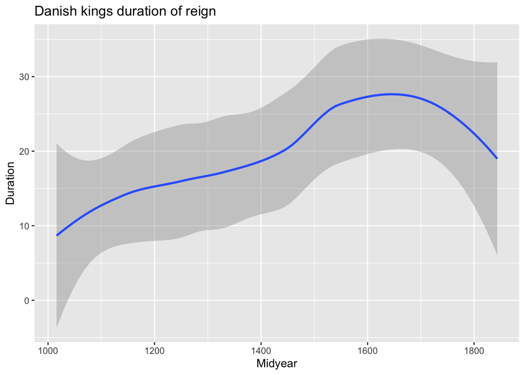

```r
kings_clean %>%
  ggplot(aes(x = midyear_1, y = duration_1)) +
  geom_smooth() +
  labs(title = "Danish kings duration of reign", x = "Midyear", y = "Duration")
```

The graph above shows the average duration of reign through time. The graph fails to inform which monarchs ruled when. Alternatively I could make a grom_point graph.

The graph below shows the kings and the midyear of their reign in a timeline. The graph below allows the viewer to get a manageable overview of the monarchs time of reign. To improve it, the order of which the kings appear should be by time of reign and not alphabet.

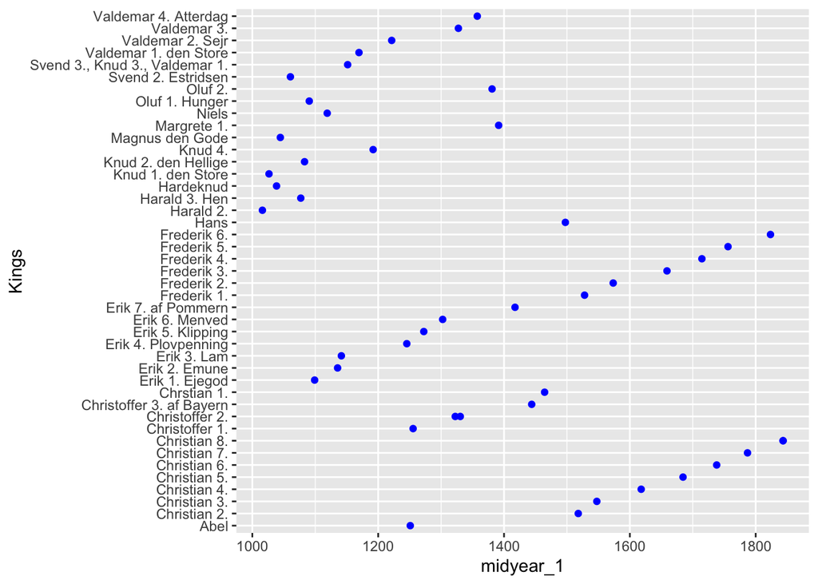

```r
ggplot(kings_clean, aes(x=midyear_1, y=Kings))+
  geom_point(colour = "blue")
```